# SHELL: COMANDOS BASICOS DE LINUX

# 3 Parte

## 3.1 Comandos de proceso

1. **ps**

Muestra los procesos que se encuentran activos en el sistema actualmente. Este comando es muy útil para saber que comandos están funcionando en un determinado momento. Algunos ejemplos de su uso

```bash
# Para ver todos sus procesos que estan asociados a algún terminal.
ps
```

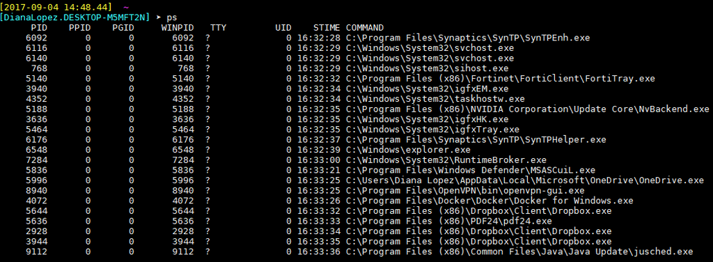

**Figura.**Procesos activos en el sistema

```bash
# Para ver todos sus procesos y los de otros usuarios siempre asociados a algún terminal.
ps a

# Para ver todos sus procesos estan asociados o no a algún terminal.
ps x
```

- PID Es el valor numérico que idenfica al proceso.
- TTY Es el terminal asociado a ese proceso. Los demonios del sistema no tienen ningún terminal asociado y en este campo figuraria un ?
- STAT Tiene tres campos que indican el estado del proceso (R,S,D,T,Z) (W) (N) La S indica que el proceso esta suspendido esperando la liberacion de un recurso (CPU, Entrada Salida, etc) necesario para continuar.
- TIME Indica el tiempo de CPU que lleva consumido ese proceso desde que fue arrancado.
- COMMAND Muestra el comando y los argumentos que le fueron comunicados.
2. **top**

Muestra todos los procesos en funcionamiento. En un sistema multitarea no se debe usar el término programa para hablar de la ejecución del mismo. En su lugar hablaremos de proceso indicando con ello que esta arrancado y funcionando. Un programa puede dar lugar a varios procesos.

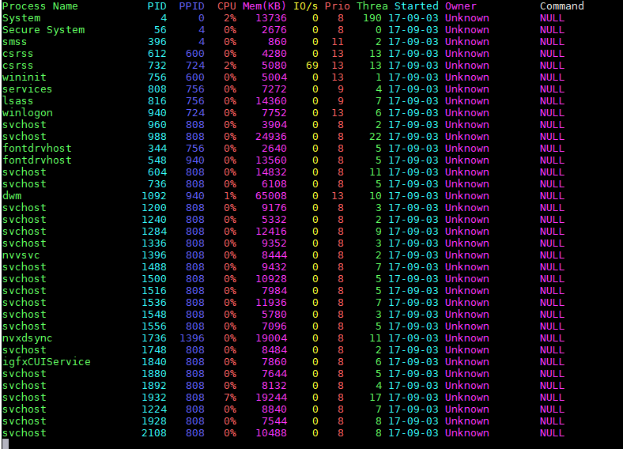

**Figura.**Procesos en funcionamiento

- **PID y PPID**: A cada proceso le correspondería un número PID que le identifica totalmente. Es decir en un mismo momento es imposible que existan dos procesos con el mismo PID. Lo mismo que todos los procesos tienen un atributo PID que es el número de proceso que lo identifica en el sistema tambien existe un atributo llamado PPID. Este numero se corresponde con el número PID del proceso padre.
- **UID y EUID**: Los procesos tienen un EUID (Efectiv User Identif), y un UID normalmente ambos coinciden. El UID es el identificador de usuario real que coincide con el identificador del usuario que arranca el proceso. El EUID es el identificador de usuario efectivo y se llama así, porque es el identinficador que se tiene en cuenta a la hora de considerar los permisos que luego explicaremos. El UID es uno de los atributos de un proceso que indica por decirlo de alguna manera quien es el propietario actual de ese proceso y en función de ello podría hacer ciertas cosas. Por ejemplo, si un usuario normal intentará eliminar un proceso del cual no es propietario el sistema no lo permitirá mostrando un mensaje de error en el que advierta que usted no es el propietario de ese proceso y por tanto no está autorizado a hacer esa operación.

```bash
## Comprobaremos cual es el UID de su directorio home.
# Cambiamos el directorio actual a home
cd
# Comprobamos a quien pertenece 'uid' y 'guid'
ls -ld .
# Ahora obtenemos el 'uid' y el 'gid' con sus valores numericos.
ls -lnd .
```

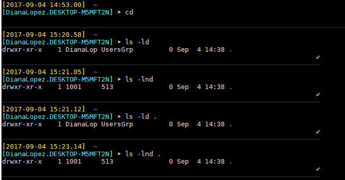

**Figura.** UID y GUID

3. **kill**

Detiene el proceso asignado al pid que muestra la salida del comando ps. En realidad envia senales a otros procesos, pero la acción por defecto asociada a la mayoría de las señales de unix es la de finalizar el proceso.

```bash
##kill "pid" (process id)
##Por ejemplo, si se quisiera matar el proceso 6548 ejecutamos:
kill 6548
##Podemos volver a correr el comando ps y observar que ya este proceso no se encuentra activo
```

**‘kill’** por defecto es **‘kill -15’** envia un SIGTERM y generalmente provoca cierre ordenado de los recursos en uso. Esta señal puede ser ignorada, o puede ser utilizada como un aviso para terminar ordenadamente. Para matar un proceso resulta recomendable enviar primero un kill -15 y si no se consigue nada repetir con **kill -9**. Este último **-9** envia SIGKILL que no puede ser ignorada, y termina inmediatamente. Solo fallará si no tenemos permisos para matar ese proceso.

4. **bg**

Muestra todos los procesos pausados o en segundo plano (recordamos que Ctrl + z establece procesos en segundo plano).

Para ejecutar un programa en background, basta con poner el signo ampersand (&) al término de la línea de comandos.

```bash
##Por ejemplo, si se quisiera copiar el archivo report.txt que esta dentro de la carpeta ecoli a la carpeta ejercicio
cp ~/ecoli/report.txt ~/ejercicio/ &
```

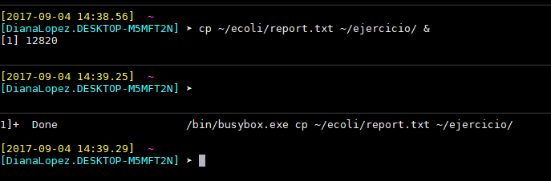

**Figura.** Comandos en background

Cuando ha terminado la ejecución del programa, el sistema lo reporta mediante un mensaje **Done**

Si se hubiese ejecutado el programa y no se hubiese puesto el ampersand, se podría pasarlo a background de la siguiente manera:

1. Se suspende la ejecucion del programa, pulsando Ctrl+Z.
2. Se ejecutamos la siguiente orden: bg
3. **fg**

Trae de vuelta el proceso mas reciente puesto en segundo plano.

## 3.2 Atajos de teclado

**Shift (Mayus) + RePag**: Realizaremos scroll hacia arriba en la terminal.

**Shift (Mayus) + AvPag**: Realizaremos scroll hacia abajo en la terminal.

**Tab (Tabulador)**: Completara el comando, nombre de fichero o directorio que estemos escribiendo. En caso de multiples coincidencias, con una doble pulsacion de esta tecla obtendremos todos los resultados posibles encontrados en el directorio o sistema.

**Flecha de direccion ‘arriba’ y /o ‘abajo’**: Nos moveremos por el historial compuesto por los últimos comandos usados.

**Ctrl + r**: Buscará en el historial el último comando usado según lo que vayamos escribiendo. Por ejemplo utilizamos el comando **clear** hace unas horas, si pulsamos Ctrl + r y escribimos **cl** nos mostrará el comando clear, puesto que lo ha buscado en el historial y es el más reciente que coincide.

**Ctrl + c**: Interrumpe cualquier proceso en ejecución de forma inmediata y nos devuelve al prompt.

**Ctrl + z**: Envia el proceso actual a segundo plano. Para recuperarlo solo tendremos que escribir **fg** y pulsar Intro.

**Ctrl + d**: Cierra la sesión de la terminal en la que nos encontramos. Si estamos usando una interfaz gráfica en la que hemos abierto una terminal, esta sólo se cerrará.

**Ctrl + w**: Elimina la palabra anterior a la posición del cursor.

**Ctrl + k**: Corta todo aquello que se encuentra entre la situación del cursor y el final de la línea.

**Ctrl + u**: Corta la línea en la que nos encontramos al completo.

**Ctrl + y**: Pega el contenido copiado o cortado con Ctrl + u o Ctrl + k.

**!!**: Repetirá el último comando usado.

## 3.3 ¿Cuánto ocupa toda la información?

Este comando contabiliza el espacio que ocupa en disco un fichero o un directorio con todos sus subdirectorios.

```bash
##Su sintaxis basica es la siguiente:
du [opciones] [ficheros...]
```

Algunas de las opciones:

-a, muestra ademas el espacio que ocupa cada uno de los ficheros que hay en los directorios que le indiquemos.

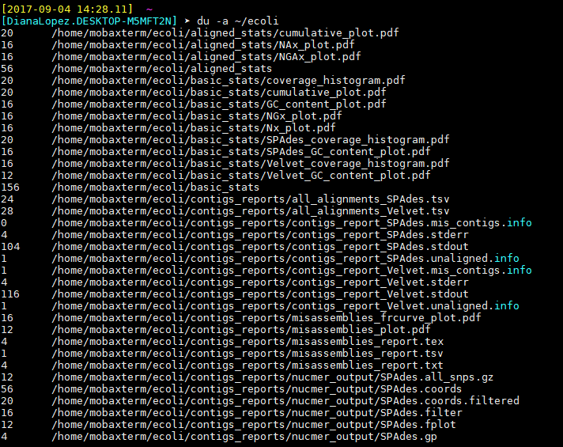

**Figura.** Ejemplo de la ejecución del comando du.

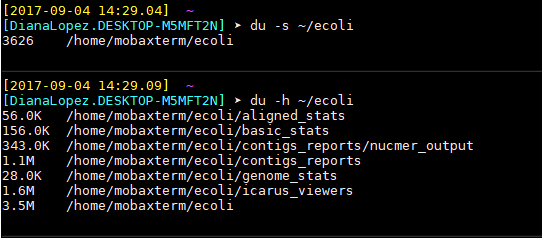

**Figura.** Ejemplo de la ejecución del comando du.

# 4 Parte

## 4.1 Programación shell

La programación es una de las herramientas más apreciadas por todos los administradores y muchos usuarios de Linux/Unix ya que permite automatizar tareas complejas, comandos repetitivos y ejecutarlas con un solo llamado al script o hacerlo automaticamente a horas escogidas sin intervención de personas.

Estos scripts pueden usar un sin número de herramientas como

- Comandos del sistema Linux/Unix (ejm: ls, cut)
- Funciones intrinsecas del shell (ejm: kill, nice)
- Lenguaje de programación del shell (ejm: if/then/else/fi)
- Programas y/o lenguajes de procesamiento en línea. (ejm: awk, sed, Perl)
- Programas propios del usuario escritos en cualquier lenguaje.

Un primer acercamiento para agrupar comandos puede ser por medio del carácter **;**. Por

```bash
##ejemplo, tecleando el comando:
$ date; ls
## Se ejecutará sucesivamente los comandos date y ls
```

También podría crearse un script con un editor de textos que contenga los comandos. Los Scripts son archivos con extensión *.sh* que se ejecutan en terminal (bash o sh).

Todos los scripts deben empezar con un conjunto de carácteres conocido como sha bang y que es: **#!/bin/bash** o **#!/bin/sh**

```bash
## abrir un editor de texto
$ nano
## se abre nano y se escriben lo sgte:

#!/bin/sh
date
ls

## Presionamos ctrl + X para salir de nano y le decimos que si guarde y ponemos un nombre, por ejemplo primer_programa.sh
```

Antes de ejecutar un script se deberá asignar permisos de ejecución: *chmod +x nombredelscript.sh* Para ejecutar un script no hay más que teclear en la terminal: *./nombredelscript*, ver figura

Si no estuvieramos en terminal bash tecleariamos entonces: *sh ./nombredelscript*

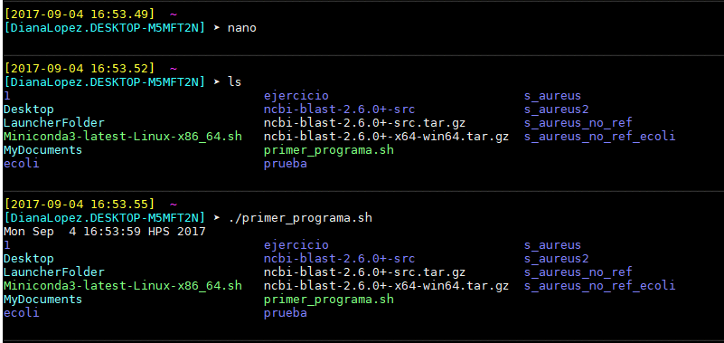

**Figura.** Ejecutando el primer_programa.sh

```bash
## Ejemplo HolaMundo.sh
## Se abre nano y se escriben lo sgte:

#!/bin/bash
clear
echo "Hola mundo ,este es mi primer script"

## Presionamos ctrl + X para salir de nano y le decimos que si guarde y ponemos un nombre, HolaMundo.sh
```

```bash
## Ejemplo ScriptUno.sh
## Se abre nano y se escriben lo sgte:

#!/bin/bash
clear
nombre="Pepito"
apellidos="Perez"
echo "Te llamas $nombre $apellidos"

## Presionamos ctrl + X para salir de nano y le decimos que si guarde y ponemos un nombre, ScriptUno.sh
```

```bash
## Ejemplo Fecha.sh
## Se abre nano y se escriben lo sgte:

#!/bin/bash
clear
fecha=`date | cut -d " " -f 1,2,3`
hora=`date | cut -d " " -f 4`
echo "Hoy es $fecha y son las $hora"

## Presionamos ctrl + X para salir de nano y le decimos que si guarde y ponemos un nombre, ScriptUno.sh
```

```bash
## Ejemplo OtroScript.sh
## Se abre nano y se escriben lo sgte:

#!/bin/bash
clear
# IFS es una variable de entorno que determina el delimitador de campos
# (que por defecto vale " "),en este script queremos cambiarlo a "," para escribir por teclado nombre,apellidos
IFS=","
read -p "Introduce el nombre,apellidos:" nombre apellidos
echo "El nombre es $nombre y los apellidos son $apellidos"

## Presionamos ctrl + X para salir de nano y le decimos que si guarde y ponemos un nombre, OtroScript.sh
```

### 4.1.1 Estructuras condicionales

Los comandos más utilizados en la creación de scripts son:

- *if* equivale a un “si”.La sintaxis es if condición Es necesario cerrarlo con un *fi*
- *else*
- *elif* equivale a un *else+if*. No es necesario cerrarlo
- *case* se utiliza cuando queremos reflejar varios casos de operación en nuestro script. Es necesario cerrarlo con un *esac*.
- *while* equivale a un “mientras que”,y sirve para indicarle al script,por ejemplo,cuando debe dejar de ejecutarse,o cuando cambiar el tipo de ejecucion
- *do;done*

La estructura básica de una condición seria:

*if* condición *then* comando1 … … *else* comando1 … … *fi*

```bash
## Ejemplo CompruebaDirectorio.sh
## Se abre nano y se escriben lo sgte:

#! /bin/bash
clear
if `cd /home/mobaxterm/ecoli/`
then
echo "Pues si, es un directorio y contiene."
ls -l
else
echo "Pues va a ser que no es un directorio"
fi

## Presionamos ctrl + X para salir de nano y le decimos que si guarde y ponemos un nombre, CompruebaDirectorio.sh
```

# 5 Parte

## 5.1 Práctica Correr un BLAST en local

Porque es interesante correr BLAST de forma local

1. Porque puede ser corrido en datos propios.
2. Porque puede ser integrado directamente a los análisis subsecuentes, y hacer parte de un mismo programa.
3. Representa mayor velocidad, al no quedar en colas dentro del servidor del NCBI.

*A continuación correremos un BLAST con los datos de secuencias ambientales*

1. Cree un nuevo directorio llamado blast:

```bash
## Desde su home:
mkdir blast
cd blast
```

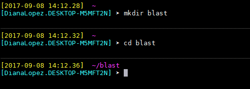

**Figura.** Creación de directorio blast

2. Copie el archivo MyQuery.fasta y rep_set.fasta de la carpeta datos, al directorio blast
3. Observe en el archivo, ¿Qué tipo de secuencias son? (nuclétidos o proteinas)

```bash
more MyQuery.fasta
more rep_set.fasta
```

4. ¿Cuántas secuencias hay en cada archivo?

```bash
grep -c '>' MyQuery.fasta
grep -c '>' rep_set.fasta
```

5. Cree la base de datos a partir del archivo rep_set.fasta

```bash
# Desde la carpeta de blast ejecutar:

../ncbi-blast-2.6.0+/bin/makeblastdb.exe -in rep_set.fasta -dbtype nucl -out My16sAmplicon
```

6. Corra un BLAST con el archivo MyQuery.fasta como “blanco” , contra la base de datos creada. Obtenga un archivo tabular.

```bash
# Desde la carpeta de blast ejecutar:
../ncbi-blast-2.6.0+/bin/blastn.exe -query MyQuery.fasta -task blastn -db My16sAmplicon -outfmt 6 -out blast_salida &
```

7. Mire el estatus de su proceso:

```bash
# Verifique con el sgte comando:
ps
```

8. cuando el trabajo termine, mire los archivos en el directorio:

```bash
# Verifique con el sgte comando:
ls
```

*Mire las cincuenta primeras líneas del resultado*

```bash
#verifique con el sgte comando:
head -50 blast_salida
```

Las columnas corresponden a:

- 1. query id
- 2. subject id
- 3. porcentaje de identidad
- 4. longitud del alíneamiento
- 5. número de “mismatches”
- 6. número de “gaps” abiertos
- 7. posición de inicio del “query”
- 8. posición de final del “query”
- 9. posición de inicio del blanco
- 10. posición de final de blanco
- 11. e-value
- 12. puntaje del alineamiento
9. ¿Cuántas secuencias tienen homología con la base de datos?

```bash
#verifique con el sgte comando:
cut -f1 blast_salida | uniq | grep -c '^'
```

10. ¿Cuántas secuencias tienen alta homología (E-value < 0.05) y al menos 90% de identidad?

```bash
#verifique con el sgte comando:
awk -F "\t" '{if ($3>90 && $11<0.05) print $1}' blast_salida | uniq | grep -c '^'
```

```bash
#verifique con el sgte comando:
awk -F "\t" '{if ($4>100 && $11<0.05) print $1}' blast_salida | uniq
```

*Guarde el resultado en un archivo*

```bash
# Verifique con el sgte comando:
awk -F "\t" '{if ($4>100 && $11<0.05) print $1}' blast_salida > resultados_filtrados
```